# Applied Statistics Project.

### First we will import all required libraries.

```python
import pandas as pd
import numpy as np
import random
%matplotlib inline
import matplotlib.pyplot as plt
import seaborn as sns
import re
import warnings
warnings.filterwarnings('ignore')
```

```python
'''
Ans:

From the above contingency table , we have total 400 people who planned to purchase and actually placed an order.

And we have total 2000 people.

So probability of the people who planned to purchase and actually placed an order is as follows:

P=Total No. of people who planned to purchase and actually placed an order / Total No. of people

'''

p=400/2000
p
```

[output not shown]

[output not shown]

```
0.2
```

### So , the Joint Probability of the people who planned to purchase and actually placed an order is 0.2 or 20 %.

```python
'''

Here  , we have given  that people planned to purchase and we have total 500 number of people who planned to purchase.

our problem statement is to find probability of the people who planned to purchase and actually placed an order.

we have such people equal to 400

so

Probability , P = Total No. of people who planned to purchase and actually placed an order / Total No. of people who planned to purchase.

'''
P=400/500
P

print("the Joint Probability of the people who planned to purchase and actually placed an order ,given people planned to purchase is",P)
```

```
the Joint Probability of the people who planned to purchase and actually placed an order ,given people planned to purchase is 0.8
```

### 2. An electrical manufacturing company conducts quality checks at specified periods on the products it manufactures. Historically, the failure rate for the manufactured item is 5%. Suppose a random sample of 10 manufactured items is selected. Answer the following questions. [4 Marks]

### 2.A. Probability that none of the items are defective? [1 Mark]

```python
# To solve this problem , we can use the binomial distribution formula which is as follows:

# P(X = 0) = (n choose x) * p^x * (1 - p)^(n - x)

# where

# n = 10 (sample size)
# x = 0 (number of defective items, here we have none of the product is defective so x =0)
# p = 0.05 (probability of an item being defective ,which is failure rate of for the manufactured item.)

# We solve this using Python code, python's scipy library provides us the binom.pmf() function, which helps to calculate the probablity mass function of the binomial distribution.

# Below is python code:


from scipy.stats import binom

n = 10  #  this is sample size
p = 0.05

# Calculate the probability using binom.pmf()
probability = binom.pmf(0, n, p)

# Print the result
print("The probability that none of the items are defective:", probability)
```

```
The probability that none of the items are defective: 0.5987369392383787
```

### Thus , we get the probability of None of the 10 item are defective = 0.5987 ( approximately = 0.6 or 60 %.)

### 2.B. Probability that exactly one of the items is defective? [1 Mark]

```python
# Ans:

# In this example also , we use the binomial distribution function :

# Here, we have to find the probability when exactly one item is defective.

# so , X=1

# We solve this problem using the python code , which is as follow


from scipy.stats import binom

n = 10  # this is our sample size
p = 0.05  # this is probability of defect (failure)

# Calculate the probability using binom.pmf()

probability = binom.pmf(1, n, p)


print("The probability of having exactly one of the items defective is :", probability)
```

```
The probability of having exactly one of the items defective is : 0.3151247048623047
```

### 2.C. Probability that two or fewer of the items are defective? [1 Mark]

```python
# Ans:

# In this example , we have to find the probability for two or fewer items are defective,

# For that we use cumulative distribution function from scipy library's binom distribution .

# Below is python code:


from scipy.stats import binom

n = 10  # this is sample size
p = 0.05  # this is probability of defect

# using the binom.cdf() function

probability = binom.cdf(2, n, p)

# Print the result
print("The probability that two or fewer of the items are defective:", probability)
```

```
The probability that two or fewer of the items are defective: 0.9884964426207031
```

### Thus , we get the probability of having two or fewer of the items defective is = 0.9885 or 98.85 %

### 2.D. Probability that three or more of the items are defective ? [1 Mark]

```python
# Ans:

# To solve this problem , we use the complement rule , because we have already calculated the probability of the complement of this statement , so to get ans. we just substract the probability value of complement from 1.

# P(three or more items defective) = 1 - P(two or fewer items defective)


1 - 0.9885
```

```
0.011499999999999955
```

### So , the probability that three or more of the 10 items are defective is approximately 0.0115 or 1.15%.

## 3. A car salesman sells on an average 3 cars per week. [3 Marks]

### 3.A. What is Probability that in a given week he will sell some cars? [1 Mark]

```python
'''Ans:

In this example ,our problem statement is to find the probability that salesman will sell some cars in given week means we need to determine the probability of selling at least one car.

Note: We can use the Poisson distribution when we know the average rate of an event occurring over a fixed interval of time.
So , To solve this example , we use the Poisson distribution ,

Average no. of cars sold per week is given as 3 .

In this example , we have given the average rate so we use Poisson distribution.

the no. of cars sold follows a Poisson distribution with lambda value as 3.

Note: Here , we can use the complementary rule , i.e
The probability of selling at least one car can be calculated as the complement of the probability of selling zero cars.

P(selling at least one car) = 1 - P(selling zero cars)

We solve this using python code which is as follows:
we can use the scipy library's poisson.pmf() function , which calculates the probability mass function of Poisson distribution.'''




from scipy.stats import poisson

avg_cars_sold = 3

# Calculate the probability using poisson.pmf()

probability = 1 - poisson.pmf(0, avg_cars_sold) # we are using the complementary rule , so we minused it from 1.


# Print the result
print("The probability of selling some cars in a given week:", probability)
```

```
The probability of selling some cars in a given week: 0.950212931632136
```

### Thus , probability of salesman will sell some cars in a given week is approximately 0.9502 or 95.02%

### 3.B. What is Probability that in a given week he will sell 2 or more but less than 5 cars? [1 Mark]

```python
'''
Ans:

Here, we again use the Poisson distribution.

In this case, the average number of cars sold per week is given as 3.

We want to calculate the probability of selling 2 or more but less than 5 cars in a week.

For that , we have to utilize the scipy library's poisson.cdf() function, which calculates the cumulative distribution function (CDF) of the Poisson distribution.

Python code is as follow :

'''


from scipy.stats import poisson

avg_cars_sold = 3

# Calculate the probability using poisson.cdf()

prob_less_tn_5 = poisson.cdf(4, avg_cars_sold)

prob_less_tn_2 = poisson.cdf(1, avg_cars_sold)

probability = prob_less_tn_5 - prob_less_tn_2

# Print the result
print("The probability of selling 2 or more but less than 5 cars in a given week:", probability)
```

```
The probability of selling 2 or more but less than 5 cars in a given week: 0.6161149710523164
```

### Thus, the probability that the car salesman will sell 2 or more but less than 5 cars in a given week is approximately 0.6161 or 61.61%.

### 3.C. Plot the poisson distribution function for cumulative probability of cars sold per-week vs number of cars sold per week. [1 Mark]

## Ans:

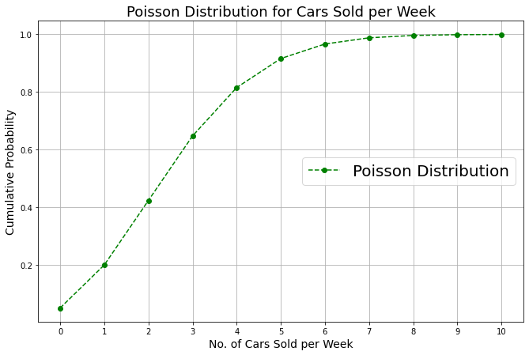

```python
import numpy as np
import matplotlib.pyplot as plt
from scipy.stats import poisson # we have to import the poisson function which is in scipy.stats module.

lambda_val = 3  # Average number of cars sold per week

x = np.arange(0, 11)  # Number of cars sold per week (from 0 to 10)
cumulative_prob = poisson.cdf(x, lambda_val)  # Cumulative probability

plt.figure(figsize=(11,7))
plt.plot(x, cumulative_prob, 'go--', label='Poisson Distribution')
plt.xlabel('No. of Cars Sold per Week',fontsize=14)
plt.ylabel('Cumulative Probability',fontsize=14)
plt.title('Poisson Distribution for Cars Sold per Week',fontsize=18)
plt.xticks(np.arange(11))
plt.legend(fontsize=20,loc=5)
plt.grid(True)
plt.show()
```

### 4. Accuracy in understanding orders for a speech based bot at a restaurant is important for the Company X which has designed, marketed and launched the product for a contactless delivery due to the COVID-19 pandemic. Recognition accuracy that measures the percentage of orders that are taken correctly is 86.8%. Suppose that you place an order with the bot and two friends of yours independently place orders with the same bot. Answer the following questions. [3 Marks] .

### 4.A. What is the probability that all three orders will be recognised correctly? [1 Mark]

```python
'''
Ans:
We can solve this problem by using the binomial distribution.

In this example , we need to find the probability that all three orders will be recognized correctly.

Binomial Distribution Formula is:
P(X = k) = (n choose k) * p^k * (1 - p)^(n - k)

where:
n = number of trials means total number of orders given to bot to recognize. (in this case, 3)
k = number of successes means bot identified orders correctly (in this case, 3)
p = probability of success which is given recognition probability = 0.868

We solve this using Python code, python's scipy library provides us the binom.pmf() function, which helps to calculate the probablity mass function of the binomial distribution.

'''


from scipy.stats import binom


p=0.868   # P -->  accuracy of recognition.
n=3       # They are total 3 persons, each can put one order so n --> = 3
k=3       # No. of orders we have given to bot to recognize.



prob = binom.pmf(k, n, p)

print(prob)

print('*'* 40)
print("Probability that all three orders will be recognized correctly by bot is :", prob )
```

```
0.653972032
Probability that all three orders will be recognized correctly by bot is : 0.653972032
```

### Thus , the probability that all three orders will be recognized correctly by the bot, using the binomial distribution, is 0.6539 or 65.39%.

### 4.B. What is the probability that none of the three orders will be recognised correctly? [1 Mark]

```python
'''
Ans:
Our problem statement state that the probability that none of the three orders will be recognized correctly , so we need to consider each order as a failure (not recognized correctly) and probability of that each failure will be (1 - 0.868) = 0.132.
we use here the binomial distribution formula,

We solve this problem using the python code which is as bellow :

'''


from scipy.stats import binom


p=0.132   # P -->  probability of not recognized correctly which is ( 1- recognized correctly)=(1-0.868)=0.132.
n=3       # They are total 3 persons, each can put one order so n --> = 3
k=3       # No. of orders recognized incorrectly .

prob = binom.pmf(k, n, p)

print("Probability that none of the three orders will be recognized correctly :", prob)
```

```
Probability that none of the three orders will be recognized correctly : 0.0022999680000000003
```

### Thus, the probability that none of the three orders will be recognized correctly by the bot, using the binomial distribution, is approximately 0.0023 or 0.23%.

### 4.C. What is the probability that at least two of the three orders will be recognised correctly? [1 Mark]

```python
'''
Ans:

From the problem statement , we need to calculate the probability of at least two of the three orders will be recognized correctly ,

so will use the binomial distribution to calculate these probabilities.

First , we calculate the probabilities of having two and three successful orders individually and then sum up them .

Python's stats library provides binomial function so we use that function to solve this problem.

'''



from scipy.stats import binom

p=0.868 # Probability of recognizing correctly.
k=2     # Number of orders recognized correclty.
n=3     # Total no. of orders given to recognize.

prob_2_correct = binom.pmf(k, n, p)
print(prob_2_correct)

print("********************************")

p=0.868 # Probability of recognizing correctly.
k=3     # Number of orders recognized correclty.
n=3     # Total no. of orders given to recognize.

prob_3_correct = binom.pmf(k, n, p)
print(prob_3_correct)

print("******************************************")
print("Probability that at least two of the three orders will be recognized correctly is :",prob_2_correct + prob_3_correct )
```

```
0.298355904
0.653972032
Probability that at least two of the three orders will be recognized correctly is : 0.952327936
```

### Therefore, the probability that at least two of the three orders will be recognized correctly by the bot is approximately 0.9523 or 95.23 %.

### 5. Explain 1 real life industry scenario (other than the ones mentioned above) where you can use the concepts learnt in this module of Applied Statistics to get data driven business solution. [3 Marks]

## Ans:

- In Banking sector , identifying the total number of fraudulent transactions occurring within particular area and within particular time frame is very important parameter in whole business life cycle of that particular bank .
- We can use the binomial distribution which will help to predict the number of fraud transactions that might occur on the following day or in the future.
- First , we should consider the assumption in binomial distribution before using the function for that particular problem statement.

#### Binomial distribution has following assumption so we will compare them with this banking sector scenario:

1. Fixed number of transactions :

   > While using the binomial distribution , there should be fixed number of transactions. So, in this banking sector scenario we have fixed number of transactions which we can check for fraud or not. Thus, this banking sector scenario satisfy our first assumption.
1. Binary outcomes:

   > In banking transaction , we only get the two output i.e transaction is fraud and not fraud, thus these outcome satisfy the second assumption of binomial distribution i.e out come should be in binary format.
1. Independent trials:

   > Here in this scenario also , each transaction is independent of one another meaning outcome of one transaction does not affect the outcome of another transaction thus this assumption is also satisfied.
1. Constant probability of success:

   > While using the Binomial distribution , probability of success should remain constant for each trial. So , we can set the probability of success of identifying the fraud transaction to a particular number . Thus, this assumption is also satisfied.

#### **Thus, all the assumption of the Binomial distribution are satisfied by the example of banking sector. So, we can easily use the Binomial distribution to identify that the transaction is fraud or not fraud.**

### We will explain this banking sector scenario with one example:

#### A bank wants to examine that within a sample of debit card transactions, what is the probability of detecting a certain number of fraud transactions. Bank has historical data , which indicates that bank has overall fraud rate of debit card transactions as 0.2%(0.002) .

- Now bank wants to determine the probability of detecting 10 fraud transaction from the given sample of 10,000 debit cards.
- To calculate this probability , we have binomial distribution function of which all the assumptions are satisfied by the baking example.
- python's stats library provides this in build's in function of binomial distribution , so we use it as bellow:

```python
from scipy.stats import binom

# Given values are:

# n --> sample_size = 10000
# p --> fraud_rate = 0.002
# k --> num_fraud_detected = 10

# probability = binom.pdf(k, n,p )


probability = binom.pmf(10, 10000,0.002 )


print("Probability of detecting 10 fraudulent transactions in the sample is :", probability)
```

```
Probability of detecting 10 fraudulent transactions in the sample is : 0.00579014500751495
```

#### Thus, Probability of detecting 10 fraudulent transactions in the sample is approximately 0.0058 or 0.58 %.

### Thus , we see that how binomial function helps banks to identify **how likely it is that a certain number of fraudulent transactions will occur in a given day within a certain volume of transactions. By setting appropriate thresholds and monitoring deviations from the expected distribution, banks can easily identify potential fraud transaction patterns and can take preventive measures on time to avoid huge loss to bank.**

# Part 2

### STEPS AND TASK [30 Marks].

### First , we will import all the required libraries:

```python
import pandas as pd
import numpy as np
%matplotlib inline
import matplotlib.pyplot as plt
import seaborn as sns
import re
```

### Q. 1. Read the data set, clean the data and prepare final dataset to be used for analysis. [10 Marks]

## Ans:

```python
df_original=pd.read_csv("DS_Part2_Basketball.csv")
```

### It is a good habit of data analyst to make copy of original data frame before performing any operation on it . Otherwise there are chances of loosing data and then we can't revert it back.

```python
df_original_copy=df_original.copy(); #take copy as original data set.
```

```python
df_original.head()
```

|  | Team | Tournament | Score | PlayedGames | WonGames | DrawnGames | LostGames | BasketScored | BasketGiven | TournamentChampion | Runner-up | TeamLaunch | HighestPositionHeld |
| --- | --- | --- | --- | --- | --- | --- | --- | --- | --- | --- | --- | --- | --- |
| 0 | Team 1 | 86 | 4385 | 2762 | 1647 | 552 | 563 | 5947 | 3140 | 33 | 23 | 1929 | 1 |
| 1 | Team 2 | 86 | 4262 | 2762 | 1581 | 573 | 608 | 5900 | 3114 | 25 | 25 | 1929 | 1 |
| 2 | Team 3 | 80 | 3442 | 2614 | 1241 | 598 | 775 | 4534 | 3309 | 10 | 8 | 1929 | 1 |
| 3 | Team 4 | 82 | 3386 | 2664 | 1187 | 616 | 861 | 4398 | 3469 | 6 | 6 | 1931to32 | 1 |
| 4 | Team 5 | 86 | 3368 | 2762 | 1209 | 633 | 920 | 4631 | 3700 | 8 | 7 | 1929 | 1 |

### We will check any duplicated rows are present in our data frame or not. For that we will use df.duplicated() method.

```python
df_original.duplicated().sum()
```

```
0
```

### Observation:

- There is no any duplicated row in our data frame.

```python
df_original.tail()
```

|  | Team | Tournament | Score | PlayedGames | WonGames | DrawnGames | LostGames | BasketScored | BasketGiven | TournamentChampion | Runner-up | TeamLaunch | HighestPositionHeld |
| --- | --- | --- | --- | --- | --- | --- | --- | --- | --- | --- | --- | --- | --- |
| 56 | Team 57 | 1 | 34 | 38 | 8 | 10 | 20 | 38 | 66 | - | - | 2009-10 | 20 |
| 57 | Team 58 | 1 | 22 | 30 | 7 | 8 | 15 | 37 | 57 | - | - | 1956-57 | 16 |
| 58 | Team 59 | 1 | 19 | 30 | 7 | 5 | 18 | 51 | 85 | - | - | 1951~52 | 16 |
| 59 | Team 60 | 1 | 14 | 30 | 5 | 4 | 21 | 34 | 65 | - | - | 1955-56 | 15 |
| 60 | Team 61 | 1 | - | - | - | - | - | - | - | - | - | 2017~18 | 9 |

### Observations :

1. Last team named 'Team 61' launched recently so we don't have many respective columns values and we can't even fill up using any logic so it's better to drop that row from original data frame.
1. All column names are in same format except 'Runner - up' column so we convert it in 'RunnerUp' format .

```python
df_original=df_original.rename(columns={'Runner-up':'RunnerUp'})
df_original.shape
```

```
(61, 13)
```

### Observations:

- In original dataframe , we have total 61 rows and 13 columns.

```python
df=df_original.drop(60)
```

```python
df.shape
```

```
(60, 13)
```

### Observation:

- After deleting last row , now we have total 60 rows in our data frame.

```python
df.tail()
```

|  | Team | Tournament | Score | PlayedGames | WonGames | DrawnGames | LostGames | BasketScored | BasketGiven | TournamentChampion | RunnerUp | TeamLaunch | HighestPositionHeld |
| --- | --- | --- | --- | --- | --- | --- | --- | --- | --- | --- | --- | --- | --- |
| 55 | Team 56 | 1 | 35 | 38 | 8 | 11 | 19 | 36 | 55 | - | - | 2016_17 | 17 |
| 56 | Team 57 | 1 | 34 | 38 | 8 | 10 | 20 | 38 | 66 | - | - | 2009-10 | 20 |
| 57 | Team 58 | 1 | 22 | 30 | 7 | 8 | 15 | 37 | 57 | - | - | 1956-57 | 16 |
| 58 | Team 59 | 1 | 19 | 30 | 7 | 5 | 18 | 51 | 85 | - | - | 1951~52 | 16 |
| 59 | Team 60 | 1 | 14 | 30 | 5 | 4 | 21 | 34 | 65 | - | - | 1955-56 | 15 |

### Now , using df.info() method , we will check information of our data frame.

```python
df.info()
```

```
<class 'pandas.core.frame.DataFrame'>
Int64Index: 60 entries, 0 to 59
Data columns (total 13 columns):
 #   Column               Non-Null Count  Dtype
---  ------               --------------  -----
 0   Team                 60 non-null     object
 1   Tournament           60 non-null     int64
 2   Score                60 non-null     object
 3   PlayedGames          60 non-null     object
 4   WonGames             60 non-null     object
 5   DrawnGames           60 non-null     object
 6   LostGames            60 non-null     object
 7   BasketScored         60 non-null     object
 8   BasketGiven          60 non-null     object
 9   TournamentChampion   60 non-null     object
 10  RunnerUp             60 non-null     object
 11  TeamLaunch           60 non-null     object
 12  HighestPositionHeld  60 non-null     int64
dtypes: int64(2), object(11)
memory usage: 6.6+ KB
```

### Observations:

1. Data frame has total 60 entries in 13 columns.
1. There is no null value in any column but small note is that values which were zero denoted with the '-' symbol so we will fill up them with specific method.
1. Only Tournament and HighestPositionHeld columns have values in int64 data type format and other remaining columns have same 'object' data type.But small note is that all values in these columns are in integer format but entered in string format so to do operations on them , we will later change them to integer or float format.

### We will check now the unique values in each column so that we will get idea about nature of every value of every column.

```python
print("Unique values in Team column are: \n \n",df.Team.unique())
print("#"*80)
print("Unique values in Tournament column are: \n \n",df.Tournament.unique())
print("#"*80)
print("Unique values in Score column are: \n \n",df.Score.unique())
print("#"*80)
print("Unique values in PlayedGames column are: \n \n",df.PlayedGames.unique())
print("#"*80)
print("Unique values in WonGames column are: \n \n",df.WonGames.unique())
print("#"*80)
print("Unique values in DrawnGames column are: \n \n",df.DrawnGames.unique())
print("#"*80)
print("Unique values in LostGames column are: \n \n",df.LostGames.unique())
print("#"*80)
print("Unique values in BasketScored column are: \n \n",df.BasketScored.unique())
print("#"*80)
print("Unique values in BasketGiven column are: \n \n",df.BasketGiven.unique())
print("#"*80)
print("Unique values in TournamentChampion column are: \n \n",df.TournamentChampion.unique())
print("#"*80)
print("Unique values in 'Runner-up' column are: \n \n",df.RunnerUp.unique())
print("#"*80)
print("Unique values in TeamLaunch column are: \n \n",df.TeamLaunch.unique())
print("#"*80)
print("Unique values in HighestPositionHeld column are: \n \n",df.HighestPositionHeld.unique())
print("#"*80)
```

```
Unique values in Team column are:

 ['Team 1' 'Team 2' 'Team 3' 'Team 4' 'Team 5' 'Team 6' 'Team 7' 'Team 8'
 'Team 9' 'Team 10' 'Team 11' 'Team 12' 'Team 13' 'Team 14' 'Team 15'
 'Team 16' 'Team 17' 'Team 18' 'Team 19' 'Team 20' 'Team 21' 'Team 22'
 'Team 23' 'Team 24' 'Team 25' 'Team 26' 'Team 27' 'Team 28' 'Team 29'
 'Team 30' 'Team 31' 'Team 32' 'Team 33' 'Team 34' 'Team 35' 'Team 36'
 'Team 37' 'Team 38' 'Team 39' 'Team 40' 'Team 41' 'Team 42' 'Team 43'
 'Team 44' 'Team 45' 'Team 46' 'Team 47' 'Team 48' 'Team 49' 'Team 50'
 'Team 51' 'Team 52' 'Team 53' 'Team 54' 'Team 55' 'Team 56' 'Team 57'
 'Team 58' 'Team 59' 'Team 60']
################################################################################
Unique values in Tournament column are:

 [86 80 82 73 70 58 51 45 42 44 43 37 36 38 27 33 17 23 21 12 20 13 18 11
 14  9  7  6  4  5  3  2  1]
################################################################################
Unique values in Score column are:

 ['4385' '4262' '3442' '3386' '3368' '2819' '2792' '2573' '2109' '1884'
 '1814' '1789' '1471' '1416' '1389' '1351' '1314' '1174' '1148' '1020'
 '970' '667' '662' '606' '553' '538' '510' '445' '421' '416' '375' '353'
 '343' '293' '285' '277' '242' '230' '190' '188' '168' '150' '148' '132'
 '107' '96' '91' '83' '81' '76' '71' '56' '52' '42' '40' '35' '34' '22'
 '19' '14']
################################################################################
Unique values in PlayedGames column are:

 ['2762' '2614' '2664' '2408' '2626' '2302' '1986' '1728' '1530' '1698'
 '1466' '1428' '1458' '1318' '1255' '1192' '988' '1096' '646' '742' '652'
 '678' '456' '628' '494' '586' '380' '402' '423' '426' '448' '346' '334'
 '270' '228' '282' '160' '186' '204' '180' '152' '114' '130' '116' '80'
 '108' '90' '72' '68' '54' '38' '30']
################################################################################
Unique values in WonGames column are:

 ['1647' '1581' '1241' '1187' '1209' '990' '948' '864' '698' '606' '563'
 '586' '463' '453' '471' '426' '390' '408' '333' '367' '266' '218' '189'
 '203' '147' '184' '155' '145' '125' '113' '123' '129' '104' '96' '103'
 '76' '62' '82' '52' '50' '59' '53' '37' '35' '43' '26' '34' '20' '19'
```

[output cut: 43 more lines]

```
################################################################################
Unique values in TeamLaunch column are:

 ['1929' '1931to32' '1934-35' '1939-40' '1932-33' '1941to42' '1948-49'
 '1944_45' '1935-36' '1949_50' '1933to34' '1960-61' '1951-52' '1998-99'
 '1941-42' '1977-78' '1959-60' '2004to05' '1961-62' '1940-41' '1930-31'
 '1963-64' '1974-75' '1943-44' '1987-88' '1991_92' '2007-08' '1962-63'
 '1994-95' '1978-79' '1971-72' '1999to00' '2014-15' '1990-91' '1947-48'
 '1996-97' '1995-96' '1945-46' '1953-54' '1979-80' '1950-51' '2016_17'
 '2009-10' '1956-57' '1951~52' '1955-56']
################################################################################
Unique values in HighestPositionHeld column are:

 [ 1  3  2  4  6  8  5 11  7 12 10 17  9 19 14 16 20 15]
################################################################################
```

## Observations:

1. In Team column, each row contains the unique value having the name of team in the label format of Team and it's number.
1. Tournament column contains the Number of played tournaments and it has integer data type so we don' t need to change it.
1. All columns named Score, PlayedGames, WonGames, DrawnGames, LostGames, BasketScored, BasketGiven, BasketGiven have all values in integer format but while entering them , written in string format so we will later change it's data type to integer or float.
1. TournamentChampion, 'Runner-up' columns contain many zero values but to denote them '-' symbol is used so we will fill all these values by 0 . We can't use mean, median or mode method here.
1. TeamLaunch columns contains the launch year of each Team but they are in range format so we will transform them taking slice of only first part of year.

```python
df.head(4)
```

|  | Team | Tournament | Score | PlayedGames | WonGames | DrawnGames | LostGames | BasketScored | BasketGiven | TournamentChampion | RunnerUp | TeamLaunch | HighestPositionHeld |
| --- | --- | --- | --- | --- | --- | --- | --- | --- | --- | --- | --- | --- | --- |
| 0 | Team 1 | 86 | 4385 | 2762 | 1647 | 552 | 563 | 5947 | 3140 | 33 | 23 | 1929 | 1 |
| 1 | Team 2 | 86 | 4262 | 2762 | 1581 | 573 | 608 | 5900 | 3114 | 25 | 25 | 1929 | 1 |
| 2 | Team 3 | 80 | 3442 | 2614 | 1241 | 598 | 775 | 4534 | 3309 | 10 | 8 | 1929 | 1 |
| 3 | Team 4 | 82 | 3386 | 2664 | 1187 | 616 | 861 | 4398 | 3469 | 6 | 6 | 1931to32 | 1 |

### We have seen that in columns TournamentChampion and RunnerUp , there are some values represented by '-' symbol. So we will see the frequency distribution of these values.

```python
print(" Frequency of values in BasketScored column are: \n \n",df.TournamentChampion.value_counts())
print("#"*80)
print(" Frequency of values in RunnerUp column are: \n \n",df.RunnerUp.value_counts())
print("#"*80)
```

```
 Frequency of values in BasketScored column are:

 -     51
1      3
6      1
8      1
10     1
25     1
33     1
2      1
Name: TournamentChampion, dtype: int64
################################################################################
 Frequency of values in RunnerUp column are:

 -     47
1      5
6      1
3      1
5      1
8      1
4      1
23     1
25     1
7      1
Name: RunnerUp, dtype: int64
################################################################################
```

### Observations :

```python
df['TournamentChampion'] = np.where(df['TournamentChampion'] =='-',0, df['TournamentChampion'])

df['RunnerUp'] = np.where(df['RunnerUp'] =='-',0, df['RunnerUp'])
```

```python
print(" Frequency of values in BasketScored column are: \n \n",df.TournamentChampion.value_counts())
print("#"*80)
print(" Frequency of values in RunnerUp column are: \n \n",df.RunnerUp.value_counts())
print("#"*80)
```

```
 Frequency of values in BasketScored column are:

 0     51
1      3
6      1
8      1
10     1
25     1
33     1
2      1
Name: TournamentChampion, dtype: int64
################################################################################
 Frequency of values in RunnerUp column are:

 0     47
1      5
6      1
3      1
5      1
8      1
4      1
23     1
25     1
7      1
Name: RunnerUp, dtype: int64
################################################################################
```

### Thus , we successfully replaced '-' these values by 0.

### As we have seen that, column TeamLaunch contains launch year of each team in year range format so we will transform it taking slice of first part of year range.

```python
df['TeamLaunch'] = df['TeamLaunch'].str.extract(r'(\d{4})')
```

```python
df.head()
```

|  | Team | Tournament | Score | PlayedGames | WonGames | DrawnGames | LostGames | BasketScored | BasketGiven | TournamentChampion | RunnerUp | TeamLaunch | HighestPositionHeld |
| --- | --- | --- | --- | --- | --- | --- | --- | --- | --- | --- | --- | --- | --- |
| 0 | Team 1 | 86 | 4385 | 2762 | 1647 | 552 | 563 | 5947 | 3140 | 33 | 23 | 1929 | 1 |
| 1 | Team 2 | 86 | 4262 | 2762 | 1581 | 573 | 608 | 5900 | 3114 | 25 | 25 | 1929 | 1 |
| 2 | Team 3 | 80 | 3442 | 2614 | 1241 | 598 | 775 | 4534 | 3309 | 10 | 8 | 1929 | 1 |
| 3 | Team 4 | 82 | 3386 | 2664 | 1187 | 616 | 861 | 4398 | 3469 | 6 | 6 | 1931 | 1 |
| 4 | Team 5 | 86 | 3368 | 2762 | 1209 | 633 | 920 | 4631 | 3700 | 8 | 7 | 1929 | 1 |

### Column Team has values in label format of Team and it's number so we convert it into short format like Tm and it's number. So it will help to show data on plot more attractively.

```python
df['Team']=df['Team'].str.replace('Team ','Tm');
```

```python
df.head(3)
```

|  | Team | Tournament | Score | PlayedGames | WonGames | DrawnGames | LostGames | BasketScored | BasketGiven | TournamentChampion | RunnerUp | TeamLaunch | HighestPositionHeld |
| --- | --- | --- | --- | --- | --- | --- | --- | --- | --- | --- | --- | --- | --- |
| 0 | Tm1 | 86 | 4385 | 2762 | 1647 | 552 | 563 | 5947 | 3140 | 33 | 23 | 1929 | 1 |
| 1 | Tm2 | 86 | 4262 | 2762 | 1581 | 573 | 608 | 5900 | 3114 | 25 | 25 | 1929 | 1 |
| 2 | Tm3 | 80 | 3442 | 2614 | 1241 | 598 | 775 | 4534 | 3309 | 10 | 8 | 1929 | 1 |

### We will check data types of each column.

```python
df.dtypes
```

```
Team                   object
Tournament              int64
Score                  object
PlayedGames            object
WonGames               object
DrawnGames             object
LostGames              object
BasketScored           object
BasketGiven            object
TournamentChampion     object
RunnerUp               object
TeamLaunch             object
HighestPositionHeld     int64
dtype: object
```

### Observations:

- Actually except column Team , all the column contains intger numbers but because of entering in string format , it showing it's data type in object format.
- So , before doing statistical analysis we will have to convert it into integer or float format . Here we will convert them into integer format.

```python
df['Score'] = df['Score'].astype('int64')
df['PlayedGames'] = df['PlayedGames'].astype('int64')
df['WonGames'] = df['WonGames'].astype('int64')
df['DrawnGames'] = df['DrawnGames'].astype('int64')
df['LostGames'] = df['LostGames'].astype('int64')
df['BasketScored'] = df['BasketScored'].astype('int64')
df['BasketGiven'] = df['BasketGiven'].astype('int64')
df['TournamentChampion'] = df['TournamentChampion'].astype('int64')
df['RunnerUp'] = df['RunnerUp'].astype('int64')
df['TeamLaunch'] = df['TeamLaunch'].astype('int64')
```

```python
df.dtypes
```

```
Team                   object
Tournament              int64
Score                   int64
PlayedGames             int64
WonGames                int64
DrawnGames              int64
LostGames               int64
BasketScored            int64
BasketGiven             int64
TournamentChampion      int64
RunnerUp                int64
TeamLaunch              int64
HighestPositionHeld     int64
dtype: object
```

```python
df.head()
```

|  | Team | Tournament | Score | PlayedGames | WonGames | DrawnGames | LostGames | BasketScored | BasketGiven | TournamentChampion | RunnerUp | TeamLaunch | HighestPositionHeld |
| --- | --- | --- | --- | --- | --- | --- | --- | --- | --- | --- | --- | --- | --- |
| 0 | Tm1 | 86 | 4385 | 2762 | 1647 | 552 | 563 | 5947 | 3140 | 33 | 23 | 1929 | 1 |
| 1 | Tm2 | 86 | 4262 | 2762 | 1581 | 573 | 608 | 5900 | 3114 | 25 | 25 | 1929 | 1 |
| 2 | Tm3 | 80 | 3442 | 2614 | 1241 | 598 | 775 | 4534 | 3309 | 10 | 8 | 1929 | 1 |
| 3 | Tm4 | 82 | 3386 | 2664 | 1187 | 616 | 861 | 4398 | 3469 | 6 | 6 | 1931 | 1 |
| 4 | Tm5 | 86 | 3368 | 2762 | 1209 | 633 | 920 | 4631 | 3700 | 8 | 7 | 1929 | 1 |

## And here , we have completed our Data Cleaning Process. Finally our Data set will look like as below.

```python
df.sample(5)
```

|  | Team | Tournament | Score | PlayedGames | WonGames | DrawnGames | LostGames | BasketScored | BasketGiven | TournamentChampion | RunnerUp | TeamLaunch | HighestPositionHeld |
| --- | --- | --- | --- | --- | --- | --- | --- | --- | --- | --- | --- | --- | --- |
| 41 | Tm42 | 6 | 150 | 180 | 53 | 44 | 83 | 165 | 221 | 0 | 0 | 1963 | 7 |
| 31 | Tm32 | 14 | 353 | 426 | 129 | 95 | 202 | 492 | 720 | 0 | 0 | 1943 | 4 |
| 36 | Tm37 | 6 | 242 | 228 | 62 | 56 | 110 | 244 | 366 | 0 | 0 | 2007 | 8 |
| 54 | Tm55 | 2 | 40 | 68 | 13 | 14 | 41 | 70 | 182 | 0 | 0 | 1950 | 16 |
| 26 | Tm27 | 13 | 510 | 494 | 155 | 128 | 211 | 619 | 744 | 0 | 0 | 1961 | 5 |

### Q. 2. Perform detailed statistical analysis and EDA using univariate, bi-variate and multivariate EDA techniques to get data driven insights on recommending which teams they can approach which will be a deal win for them. Also as a data and statistics expert you have to develop a detailed performance report using this data. [10 Marks]

Hint: Use statistical techniques and visualisation techniques to come up with useful metrics and reporting. Find out the best performing team, oldest team, team with highest goals, team with lowest performance etc. and many more. These are just random examples. Please use your best analytical approach to build this report. You can mix match columns to create new ones which can be used for better analysis. Create your own features if required. Be highly experimental and analytical here to find hidden patterns. Use graphical interactive libraries to enable you to publish interactive plots in python

### Now , we will do statistical analysis using df.describe() method.

```python
df.describe(include='all').T  # include= 'all' --> given the statistical information of all columns present in data set.Otherwise by default , we only get info. of numberical columns.
```

|  | count | unique | top | freq | mean | std | min | 25% | 50% | 75% | max |
| --- | --- | --- | --- | --- | --- | --- | --- | --- | --- | --- | --- |
| Team | 60 | 60 | Tm36 | 1 | NaN | NaN | NaN | NaN | NaN | NaN | NaN |
| Tournament | 60.0 | NaN | NaN | NaN | 24.383333 | 26.88462 | 1.0 | 4.0 | 12.0 | 39.0 | 86.0 |
| Score | 60.0 | NaN | NaN | NaN | 916.45 | 1138.342899 | 14.0 | 104.25 | 395.5 | 1360.5 | 4385.0 |
| PlayedGames | 60.0 | NaN | NaN | NaN | 810.1 | 877.465393 | 30.0 | 115.5 | 424.5 | 1345.5 | 2762.0 |
| WonGames | 60.0 | NaN | NaN | NaN | 309.033333 | 408.481395 | 5.0 | 34.75 | 124.0 | 432.75 | 1647.0 |
| DrawnGames | 60.0 | NaN | NaN | NaN | 192.083333 | 201.985508 | 4.0 | 26.25 | 98.5 | 331.5 | 633.0 |
| LostGames | 60.0 | NaN | NaN | NaN | 308.816667 | 294.508639 | 15.0 | 62.75 | 197.5 | 563.5 | 1070.0 |
| BasketScored | 60.0 | NaN | NaN | NaN | 1159.35 | 1512.063948 | 34.0 | 154.5 | 444.0 | 1669.75 | 5947.0 |
| BasketGiven | 60.0 | NaN | NaN | NaN | 1159.233333 | 1163.946914 | 55.0 | 236.0 | 632.5 | 2001.25 | 3889.0 |
| TournamentChampion | 60.0 | NaN | NaN | NaN | 1.45 | 5.51554 | 0.0 | 0.0 | 0.0 | 0.0 | 33.0 |
| RunnerUp | 60.0 | NaN | NaN | NaN | 1.433333 | 4.574679 | 0.0 | 0.0 | 0.0 | 0.0 | 25.0 |
| TeamLaunch | 60.0 | NaN | NaN | NaN | 1957.95 | 26.646732 | 1929.0 | 1934.75 | 1950.5 | 1977.25 | 2016.0 |
| HighestPositionHeld | 60.0 | NaN | NaN | NaN | 7.05 | 5.315232 | 1.0 | 3.0 | 6.0 | 10.0 | 20.0 |

### We will check the symmetry of the data distribution using df.skew() function.

### Information about skewness :

#### The skewness values indicate the degree of asymmetry in the distribution of data.

- If the skewness value is close to 0, the distribution is approximately symmetric.
- If the skewness value is negative, the distribution is left-skewed or negatively skewed, with a longer left tail.
- And , If the skewness value is positive, the distribution is right-skewed or positively skewed, with a longer right tail.

```python
df.skew()
```

```
Tournament             1.197176
Score                  1.574104
PlayedGames            1.123454
WonGames               1.786067
DrawnGames             0.984899
LostGames              0.880596
BasketScored           1.758058
BasketGiven            0.958164
TournamentChampion     4.734845
RunnerUp               4.321794
TeamLaunch             0.682570
HighestPositionHeld    0.832164
dtype: float64
```

### Observations:

1. All columns data have skew values greater than 0 so they all are positively skewed with longer right tail.
1. TournamentChampion and RunnerUp columns have the highest skewness value almost greater than 4 so these two columns are highly right skewed.
1. All other columns also have skewness value almost close to 1 or '> 1' . So, all they are right skewed with longer right tail.

### We will see the distribution of Team Launch column.

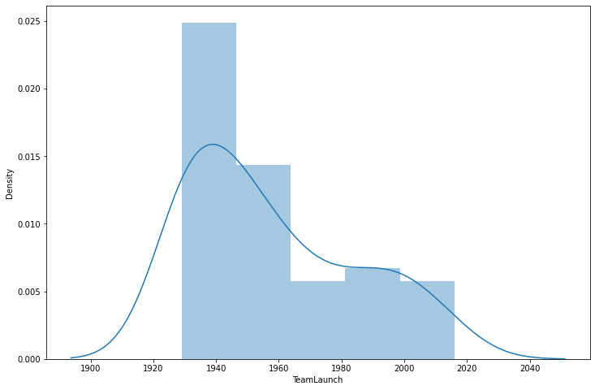

```python
plt.figure(figsize=(12,8))
sns.distplot(df.TeamLaunch)
```

### Observation:

- Maximum team are launched in the year range between 1930 to 1965.

### Let's see the distribution of Score column using matplotlibs hist function.

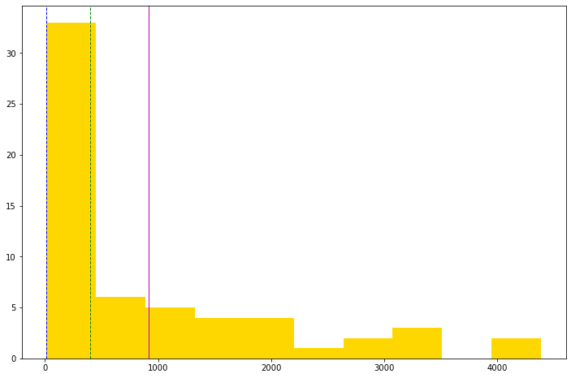

```python
plt.figure(figsize=(12,8))
plt.hist(df.Score,color='gold') ;# plots a simple histogram
plt.axvline(df.Score.mean(), color='m', linewidth=1)
plt.axvline(df.Score.median(), color='g', linestyle='dashed', linewidth=1)
plt.axvline(df.Score.mode()[0], color='b', linestyle='dashed', linewidth=1);
```

### Observations:

1. Within first bin out of ten bins , approximately 35 teams out of 60 have score lied in that first bin.
1. Very few teams got close to 4000 score.But we can't treat them as outliers because in sport there is tendency that very few team wins repetitively.
1. We don't have any single team who's score is in between 3500 to 4000 range.
1. We have very few teams who have score more than 1500.
1. From the plot , we can see that , Mean and Median are lied far apart and median is located left to mean so score data is right skewed.

### We plot the distribution of each column in the data set using the sns.boxplot() method.

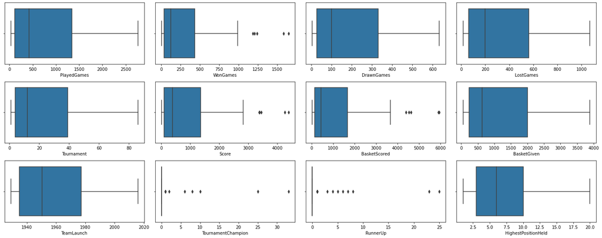

```python
fig, ax = plt.subplots(3, 4)

fig.set_figheight(8)
fig.set_figwidth(20)

sns.boxplot(x=df.PlayedGames,ax=ax[0][0]);
sns.boxplot(x=df.WonGames,ax=ax[0][1]);
sns.boxplot(x=df.DrawnGames,ax=ax[0][2]);
sns.boxplot(x=df.LostGames,ax=ax[0][3]);


sns.boxplot(x=df.Tournament,ax=ax[1][0]);
sns.boxplot(x=df.Score,ax=ax[1][1]);
sns.boxplot(x=df.BasketScored,ax=ax[1][2]);
sns.boxplot(x=df.BasketGiven,ax=ax[1][3]);

sns.boxplot(x=df.TeamLaunch,ax=ax[2][0]);
sns.boxplot(x=df.TournamentChampion,ax=ax[2][1]);
sns.boxplot(x=df.RunnerUp,ax=ax[2][2]);
sns.boxplot(x=df.HighestPositionHeld,ax=ax[2][3]);

fig.tight_layout()
plt.show();
```

### From WinGames, DrawnGames, LostGames ,TournamentChampion and RunnerUp column values we are not getting clear cut idea about it's distribution, so we will create the new columns containing it's percentage values.

```python
# new_df=df[['Team','TeamLaunch','TeamLaunchCategory','PlayedGames','HighestPositionHeld']]
df['WinPercent']=round((df.WonGames/ df.PlayedGames)*100,2)
df['DrawnPercent']=round((df.DrawnGames/ df.PlayedGames)*100,2)
df['LostPercent']=round((df.LostGames/ df.PlayedGames)*100,2)
df['TournamentChampionPercent']=round((df.TournamentChampion/ df.Tournament)*100,2)
df['RunnerUpPercent']=round((df.RunnerUp/ df.Tournament)*100,2)

#performaceMatrix.describe()
```

```python
df.head(4)
```

|  | Team | Tournament | Score | PlayedGames | WonGames | DrawnGames | LostGames | BasketScored | BasketGiven | TournamentChampion | RunnerUp | TeamLaunch | HighestPositionHeld | WinPercent | DrawnPercent | LostPercent | TournamentChampionPercent | RunnerUpPercent |
| --- | --- | --- | --- | --- | --- | --- | --- | --- | --- | --- | --- | --- | --- | --- | --- | --- | --- | --- |
| 0 | Tm1 | 86 | 4385 | 2762 | 1647 | 552 | 563 | 5947 | 3140 | 33 | 23 | 1929 | 1 | 59.63 | 19.99 | 20.38 | 38.37 | 26.74 |
| 1 | Tm2 | 86 | 4262 | 2762 | 1581 | 573 | 608 | 5900 | 3114 | 25 | 25 | 1929 | 1 | 57.24 | 20.75 | 22.01 | 29.07 | 29.07 |
| 2 | Tm3 | 80 | 3442 | 2614 | 1241 | 598 | 775 | 4534 | 3309 | 10 | 8 | 1929 | 1 | 47.48 | 22.88 | 29.65 | 12.50 | 10.00 |
| 3 | Tm4 | 82 | 3386 | 2664 | 1187 | 616 | 861 | 4398 | 3469 | 6 | 6 | 1931 | 1 | 44.56 | 23.12 | 32.32 | 7.32 | 7.32 |

### Now , we will plot the percentage of winning , lost and drawn category

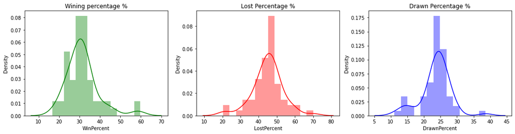

```python
import warnings
warnings.filterwarnings('ignore')
fig, ax = plt.subplots(1, 3)

fig.set_figheight(4) # Here , using figheight methods of fig. we have set it's height and width.
fig.set_figwidth(18)

sns.distplot(df['WinPercent'], ax = ax[0],color='g')
sns.distplot(df['LostPercent'], ax = ax[1],color='r')
sns.distplot(df['DrawnPercent'], ax = ax[2],color='b')

ax[0].set_title('Wining percentage %')
ax[1].set_title('Lost Percentage %')
ax[2].set_title('Drawn Percentage %')
plt.show();
```

### Observation:

1. we can see that data distribution in percentage of WinPercentage, LostPercentage and DrawnPercentage have same shape.
1. Many teams have highest frequency of winning percentage , in 25 % to 35 %.
1. 40% to 50% Lost Percentage bin size containing maximum number of teams.

### We will create one categorical column having name TeamLaunchCategory by giving 4 labels based on their TeamLaunch Year using pandas pd.qcut() method.

```python
df['TeamLaunchCategory'] = (pd.qcut(df['TeamLaunch'], 4, labels=['VeryOld', 'Old', 'New', 'VeryNew']));
df.sample(5)
```

|  | Team | Tournament | Score | PlayedGames | WonGames | DrawnGames | LostGames | BasketScored | BasketGiven | TournamentChampion | RunnerUp | TeamLaunch | HighestPositionHeld | WinPercent | DrawnPercent | LostPercent | TournamentChampionPercent | RunnerUpPercent | TeamLaunchCategory |
| --- | --- | --- | --- | --- | --- | --- | --- | --- | --- | --- | --- | --- | --- | --- | --- | --- | --- | --- | --- |
| 3 | Tm4 | 82 | 3386 | 2664 | 1187 | 616 | 861 | 4398 | 3469 | 6 | 6 | 1931 | 1 | 44.56 | 23.12 | 32.32 | 7.32 | 7.32 | VeryOld |
| 39 | Tm40 | 5 | 188 | 186 | 50 | 46 | 90 | 202 | 296 | 0 | 0 | 1978 | 8 | 26.88 | 24.73 | 48.39 | 0.00 | 0.00 | VeryNew |
| 27 | Tm28 | 18 | 445 | 586 | 145 | 143 | 298 | 607 | 992 | 0 | 0 | 1940 | 11 | 24.74 | 24.40 | 50.85 | 0.00 | 0.00 | Old |
| 45 | Tm46 | 3 | 96 | 114 | 26 | 44 | 44 | 101 | 139 | 0 | 0 | 1990 | 9 | 22.81 | 38.60 | 38.60 | 0.00 | 0.00 | VeryNew |
| 49 | Tm50 | 4 | 76 | 108 | 30 | 16 | 62 | 145 | 252 | 0 | 0 | 1945 | 10 | 27.78 | 14.81 | 57.41 | 0.00 | 0.00 | Old |

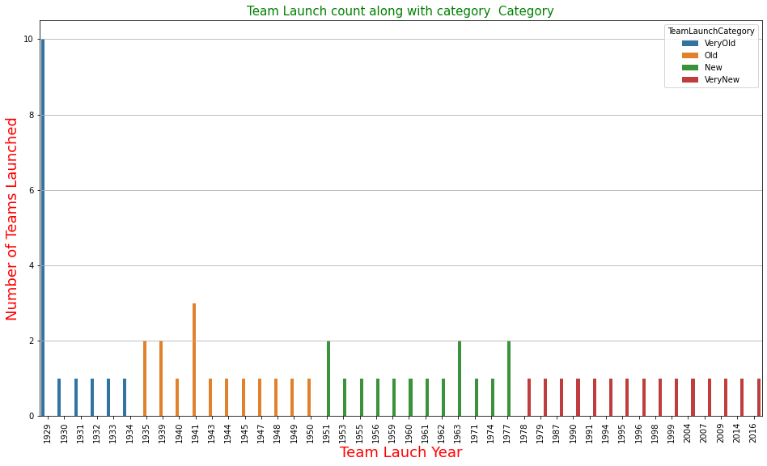

```python
plt.figure(figsize=(16,9))
sns.countplot(df.TeamLaunch,hue=df.TeamLaunchCategory)
plt.title("Team Launch count along with category  Category",size=15,color='g')
plt.xticks(rotation=90);
plt.grid(axis='y')
plt.xlabel('Team Lauch Year' , fontsize=18,color='r')
plt.ylabel('Number of Teams Launched', fontsize=18,color='r');
```

### Observations:

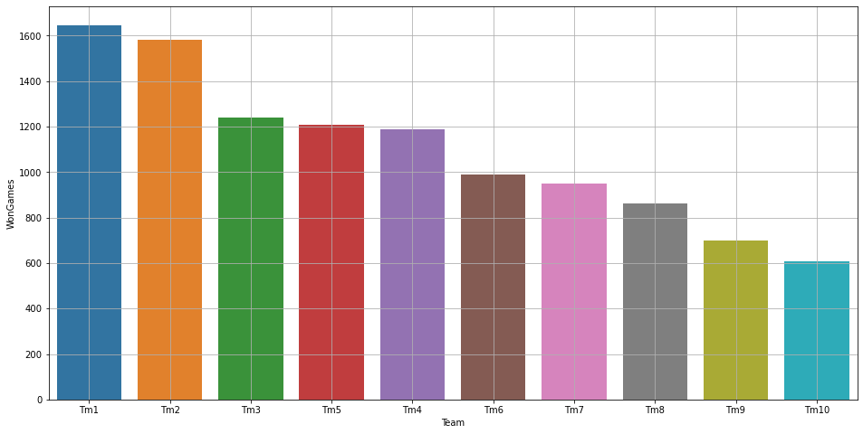

```python
# Details of the top 10 winning teams

df_wongames= df.nlargest(10, ['WonGames'])
plt.figure(figsize=(16,8))
sns.barplot(data=df_wongames,x='Team',y='WonGames')
plt.grid()
plt.show()
```

### Let's we see the correlation among the columns .

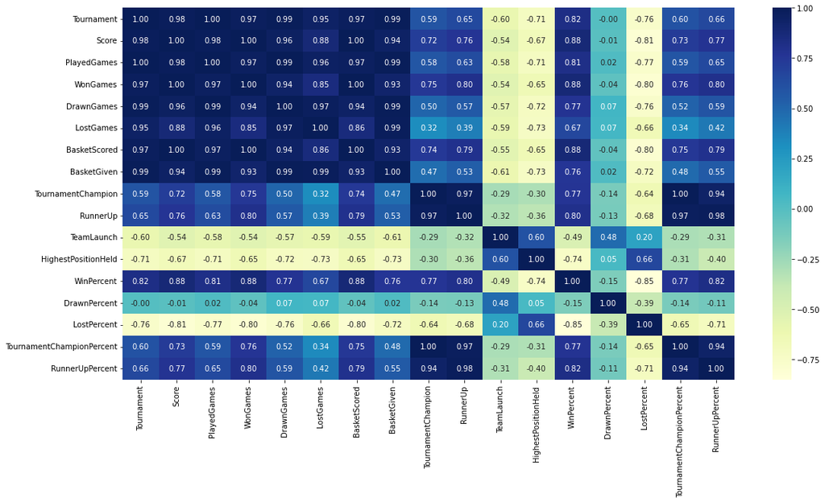

```python
plt.figure(figsize=(18,9))
corrmat = df.corr(method='pearson')
sns.heatmap(corrmat, cmap="YlGnBu", fmt='.2f',annot=True)
plt.show();
```

### We will show the relation among each pair of columns using seaborn's pairplot function.

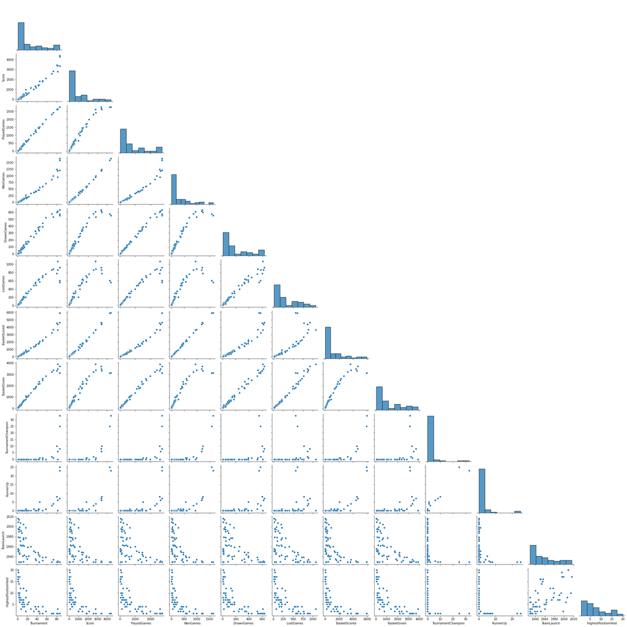

```python
plt.figure(figsize=(10,5))
pairplot=sns.pairplot(df[['Tournament', 'Score', 'PlayedGames', 'WonGames', 'DrawnGames',
       'LostGames', 'BasketScored', 'BasketGiven', 'TournamentChampion',
       'RunnerUp', 'TeamLaunch', 'HighestPositionHeld',
       ]],corner=True);
plt.show();
```

### Observation:

- We can see from the above plot that there are many columns which have highest correlation between them.

### Top 10 teams in the given list with Hightest winning percentage:

```python
df.sort_values(['WinPercent'],ascending=[False]).head(10)
```

|  | Team | Tournament | Score | PlayedGames | WonGames | DrawnGames | LostGames | BasketScored | BasketGiven | TournamentChampion | RunnerUp | TeamLaunch | HighestPositionHeld | WinPercent | DrawnPercent | LostPercent | TournamentChampionPercent | RunnerUpPercent | TeamLaunchCategory |
| --- | --- | --- | --- | --- | --- | --- | --- | --- | --- | --- | --- | --- | --- | --- | --- | --- | --- | --- | --- |
| 0 | Tm1 | 86 | 4385 | 2762 | 1647 | 552 | 563 | 5947 | 3140 | 33 | 23 | 1929 | 1 | 59.63 | 19.99 | 20.38 | 38.37 | 26.74 | VeryOld |
| 1 | Tm2 | 86 | 4262 | 2762 | 1581 | 573 | 608 | 5900 | 3114 | 25 | 25 | 1929 | 1 | 57.24 | 20.75 | 22.01 | 29.07 | 29.07 | VeryOld |
| 2 | Tm3 | 80 | 3442 | 2614 | 1241 | 598 | 775 | 4534 | 3309 | 10 | 8 | 1929 | 1 | 47.48 | 22.88 | 29.65 | 12.50 | 10.00 | VeryOld |
| 3 | Tm4 | 82 | 3386 | 2664 | 1187 | 616 | 861 | 4398 | 3469 | 6 | 6 | 1931 | 1 | 44.56 | 23.12 | 32.32 | 7.32 | 7.32 | VeryOld |
| 4 | Tm5 | 86 | 3368 | 2762 | 1209 | 633 | 920 | 4631 | 3700 | 8 | 7 | 1929 | 1 | 43.77 | 22.92 | 33.31 | 9.30 | 8.14 | VeryOld |
| 20 | Tm21 | 17 | 970 | 646 | 266 | 172 | 208 | 892 | 789 | 0 | 1 | 1998 | 2 | 41.18 | 26.63 | 32.20 | 0.00 | 5.88 | VeryNew |
| 5 | Tm6 | 73 | 2819 | 2408 | 990 | 531 | 887 | 3680 | 3373 | 1 | 4 | 1934 | 1 | 41.11 | 22.05 | 36.84 | 1.37 | 5.48 | VeryOld |
| 7 | Tm8 | 70 | 2573 | 2302 | 864 | 577 | 861 | 3228 | 3230 | 2 | 3 | 1929 | 1 | 37.53 | 25.07 | 37.40 | 2.86 | 4.29 | VeryOld |
| 10 | Tm11 | 45 | 1814 | 1530 | 563 | 392 | 575 | 2052 | 2188 | 1 | 5 | 1941 | 1 | 36.80 | 25.62 | 37.58 | 2.22 | 11.11 | Old |
| 6 | Tm7 | 82 | 2792 | 2626 | 948 | 608 | 1070 | 3609 | 3889 | 0 | 0 | 1929 | 3 | 36.10 | 23.15 | 40.75 | 0.00 | 0.00 | VeryOld |

### Best performed Team in Given data set

```python
df[(df.WinPercent==df.WinPercent.max()) & (df.LostPercent==df.LostPercent.min() )]
```

|  | Team | Tournament | Score | PlayedGames | WonGames | DrawnGames | LostGames | BasketScored | BasketGiven | TournamentChampion | RunnerUp | TeamLaunch | HighestPositionHeld | WinPercent | DrawnPercent | LostPercent | TournamentChampionPercent | RunnerUpPercent | TeamLaunchCategory |
| --- | --- | --- | --- | --- | --- | --- | --- | --- | --- | --- | --- | --- | --- | --- | --- | --- | --- | --- | --- |
| 0 | Tm1 | 86 | 4385 | 2762 | 1647 | 552 | 563 | 5947 | 3140 | 33 | 23 | 1929 | 1 | 59.63 | 19.99 | 20.38 | 38.37 | 26.74 | VeryOld |

### Observations:

1. Best performed team will be such team which has maximum winning percentage and minimum lost percentage .
1. **Team 1** which is launched very early so that team played many tournaments as well that team won many games. So it is at highest rank according to teams performance.

### Top 10 winning teams in Given data set excluding very old teams

```python
df[df.TeamLaunchCategory != 'VeryOld'].sort_values(['WinPercent'],ascending=[False]).head(10)
```

|  | Team | Tournament | Score | PlayedGames | WonGames | DrawnGames | LostGames | BasketScored | BasketGiven | TournamentChampion | RunnerUp | TeamLaunch | HighestPositionHeld | WinPercent | DrawnPercent | LostPercent | TournamentChampionPercent | RunnerUpPercent | TeamLaunchCategory |
| --- | --- | --- | --- | --- | --- | --- | --- | --- | --- | --- | --- | --- | --- | --- | --- | --- | --- | --- | --- |
| 20 | Tm21 | 17 | 970 | 646 | 266 | 172 | 208 | 892 | 789 | 0 | 1 | 1998 | 2 | 41.18 | 26.63 | 32.20 | 0.00 | 5.88 | VeryNew |
| 10 | Tm11 | 45 | 1814 | 1530 | 563 | 392 | 575 | 2052 | 2188 | 1 | 5 | 1941 | 1 | 36.80 | 25.62 | 37.58 | 2.22 | 11.11 | Old |
| 8 | Tm9 | 58 | 2109 | 1986 | 698 | 522 | 766 | 2683 | 2847 | 0 | 1 | 1939 | 2 | 35.15 | 26.28 | 38.57 | 0.00 | 1.72 | Old |
| 11 | Tm12 | 51 | 1789 | 1698 | 586 | 389 | 723 | 2278 | 2624 | 0 | 0 | 1939 | 4 | 34.51 | 22.91 | 42.58 | 0.00 | 0.00 | Old |
| 18 | Tm19 | 27 | 1148 | 988 | 333 | 256 | 399 | 1182 | 1371 | 0 | 0 | 1960 | 3 | 33.70 | 25.91 | 40.38 | 0.00 | 0.00 | New |
| 19 | Tm20 | 33 | 1020 | 1096 | 367 | 242 | 487 | 1347 | 1746 | 0 | 1 | 1951 | 2 | 33.49 | 22.08 | 44.43 | 0.00 | 3.03 | New |
| 38 | Tm39 | 4 | 190 | 160 | 52 | 45 | 63 | 199 | 241 | 0 | 0 | 1994 | 10 | 32.50 | 28.12 | 39.38 | 0.00 | 0.00 | VeryNew |
| 15 | Tm16 | 37 | 1351 | 1318 | 426 | 327 | 565 | 1500 | 1834 | 0 | 0 | 1935 | 4 | 32.32 | 24.81 | 42.87 | 0.00 | 0.00 | Old |
| 14 | Tm15 | 43 | 1389 | 1458 | 471 | 358 | 629 | 1753 | 2152 | 0 | 1 | 1944 | 2 | 32.30 | 24.55 | 43.14 | 0.00 | 2.33 | Old |
| 24 | Tm25 | 12 | 553 | 456 | 147 | 112 | 197 | 520 | 633 | 0 | 0 | 2004 | 6 | 32.24 | 24.56 | 43.20 | 0.00 | 0.00 | VeryNew |

### Observations:

1. Team21, Team11, Team9, Team12, Team19, Team20, Team39, Team16, Team15 and Team25 have the high winning percentage values .So management of Company X should reach out to these teams.

### Teams with High Targets

```python
df[(df.PlayedGames==df.PlayedGames.max())]
```

|  | Team | Tournament | Score | PlayedGames | WonGames | DrawnGames | LostGames | BasketScored | BasketGiven | TournamentChampion | RunnerUp | TeamLaunch | HighestPositionHeld | WinPercent | DrawnPercent | LostPercent | TournamentChampionPercent | RunnerUpPercent | TeamLaunchCategory |
| --- | --- | --- | --- | --- | --- | --- | --- | --- | --- | --- | --- | --- | --- | --- | --- | --- | --- | --- | --- |
| 0 | Tm1 | 86 | 4385 | 2762 | 1647 | 552 | 563 | 5947 | 3140 | 33 | 23 | 1929 | 1 | 59.63 | 19.99 | 20.38 | 38.37 | 26.74 | VeryOld |
| 1 | Tm2 | 86 | 4262 | 2762 | 1581 | 573 | 608 | 5900 | 3114 | 25 | 25 | 1929 | 1 | 57.24 | 20.75 | 22.01 | 29.07 | 29.07 | VeryOld |
| 4 | Tm5 | 86 | 3368 | 2762 | 1209 | 633 | 920 | 4631 | 3700 | 8 | 7 | 1929 | 1 | 43.77 | 22.92 | 33.31 | 9.30 | 8.14 | VeryOld |

### Observations:

1. Above teams have launched in the tournament. So they have played the maximum number on games. So they have high values related to Score ,PlayedGames , Wongames etc.

### Teams with Low Targets

```python
(df.sort_values(['PlayedGames'],ascending=[True])).head(3)
```

|  | Team | Tournament | Score | PlayedGames | WonGames | DrawnGames | LostGames | BasketScored | BasketGiven | TournamentChampion | RunnerUp | TeamLaunch | HighestPositionHeld | WinPercent | DrawnPercent | LostPercent | TournamentChampionPercent | RunnerUpPercent | TeamLaunchCategory |
| --- | --- | --- | --- | --- | --- | --- | --- | --- | --- | --- | --- | --- | --- | --- | --- | --- | --- | --- | --- |
| 59 | Tm60 | 1 | 14 | 30 | 5 | 4 | 21 | 34 | 65 | 0 | 0 | 1955 | 15 | 16.67 | 13.33 | 70.0 | 0.0 | 0.0 | New |
| 57 | Tm58 | 1 | 22 | 30 | 7 | 8 | 15 | 37 | 57 | 0 | 0 | 1956 | 16 | 23.33 | 26.67 | 50.0 | 0.0 | 0.0 | New |
| 58 | Tm59 | 1 | 19 | 30 | 7 | 5 | 18 | 51 | 85 | 0 | 0 | 1951 | 16 | 23.33 | 16.67 | 60.0 | 0.0 | 0.0 | New |

### Teams that has high rank in position.

```python
(df.sort_values(['HighestPositionHeld'],ascending=[False])).head(1)
```

|  | Team | Tournament | Score | PlayedGames | WonGames | DrawnGames | LostGames | BasketScored | BasketGiven | TournamentChampion | RunnerUp | TeamLaunch | HighestPositionHeld | WinPercent | DrawnPercent | LostPercent | TournamentChampionPercent | RunnerUpPercent | TeamLaunchCategory |
| --- | --- | --- | --- | --- | --- | --- | --- | --- | --- | --- | --- | --- | --- | --- | --- | --- | --- | --- | --- |
| 56 | Tm57 | 1 | 34 | 38 | 8 | 10 | 20 | 38 | 66 | 0 | 0 | 2009 | 20 | 21.05 | 26.32 | 52.63 | 0.0 | 0.0 | VeryNew |

### Observations:

- Team 57 have performed very poorly with respect to all others teams so management should not approch to them.

```python
df.sort_values(['DrawnPercent'],ascending=[False]).head(5)
```

|  | Team | Tournament | Score | PlayedGames | WonGames | DrawnGames | LostGames | BasketScored | BasketGiven | TournamentChampion | RunnerUp | TeamLaunch | HighestPositionHeld | WinPercent | DrawnPercent | LostPercent | TournamentChampionPercent | RunnerUpPercent | TeamLaunchCategory |
| --- | --- | --- | --- | --- | --- | --- | --- | --- | --- | --- | --- | --- | --- | --- | --- | --- | --- | --- | --- |
| 45 | Tm46 | 3 | 96 | 114 | 26 | 44 | 44 | 101 | 139 | 0 | 0 | 1990 | 9 | 22.81 | 38.60 | 38.60 | 0.0 | 0.0 | VeryNew |
| 48 | Tm49 | 2 | 81 | 80 | 19 | 24 | 37 | 70 | 115 | 0 | 0 | 1995 | 19 | 23.75 | 30.00 | 46.25 | 0.0 | 0.0 | VeryNew |
| 55 | Tm56 | 1 | 35 | 38 | 8 | 11 | 19 | 36 | 55 | 0 | 0 | 2016 | 17 | 21.05 | 28.95 | 50.00 | 0.0 | 0.0 | VeryNew |
| 47 | Tm48 | 2 | 83 | 80 | 20 | 23 | 37 | 62 | 117 | 0 | 0 | 1996 | 17 | 25.00 | 28.75 | 46.25 | 0.0 | 0.0 | VeryNew |
| 32 | Tm33 | 12 | 343 | 448 | 104 | 127 | 217 | 393 | 662 | 0 | 0 | 1977 | 12 | 23.21 | 28.35 | 48.44 | 0.0 | 0.0 | New |

### Observations:

1. These Team46, Team49, Team56, Team48, Team33 mentioned teams have higher percentage of draw so by giving more focus and by providing more practice to them company X management can change this draw percentage to winning percentage.

```python
df.sort_values(['WinPercent'],ascending=[False]).head(10)
```

|  | Team | Tournament | Score | PlayedGames | WonGames | DrawnGames | LostGames | BasketScored | BasketGiven | TournamentChampion | RunnerUp | TeamLaunch | HighestPositionHeld | WinPercent | DrawnPercent | LostPercent | TournamentChampionPercent | RunnerUpPercent | TeamLaunchCategory |
| --- | --- | --- | --- | --- | --- | --- | --- | --- | --- | --- | --- | --- | --- | --- | --- | --- | --- | --- | --- |
| 0 | Tm1 | 86 | 4385 | 2762 | 1647 | 552 | 563 | 5947 | 3140 | 33 | 23 | 1929 | 1 | 59.63 | 19.99 | 20.38 | 38.37 | 26.74 | VeryOld |
| 1 | Tm2 | 86 | 4262 | 2762 | 1581 | 573 | 608 | 5900 | 3114 | 25 | 25 | 1929 | 1 | 57.24 | 20.75 | 22.01 | 29.07 | 29.07 | VeryOld |
| 2 | Tm3 | 80 | 3442 | 2614 | 1241 | 598 | 775 | 4534 | 3309 | 10 | 8 | 1929 | 1 | 47.48 | 22.88 | 29.65 | 12.50 | 10.00 | VeryOld |
| 3 | Tm4 | 82 | 3386 | 2664 | 1187 | 616 | 861 | 4398 | 3469 | 6 | 6 | 1931 | 1 | 44.56 | 23.12 | 32.32 | 7.32 | 7.32 | VeryOld |
| 4 | Tm5 | 86 | 3368 | 2762 | 1209 | 633 | 920 | 4631 | 3700 | 8 | 7 | 1929 | 1 | 43.77 | 22.92 | 33.31 | 9.30 | 8.14 | VeryOld |
| 20 | Tm21 | 17 | 970 | 646 | 266 | 172 | 208 | 892 | 789 | 0 | 1 | 1998 | 2 | 41.18 | 26.63 | 32.20 | 0.00 | 5.88 | VeryNew |
| 5 | Tm6 | 73 | 2819 | 2408 | 990 | 531 | 887 | 3680 | 3373 | 1 | 4 | 1934 | 1 | 41.11 | 22.05 | 36.84 | 1.37 | 5.48 | VeryOld |
| 7 | Tm8 | 70 | 2573 | 2302 | 864 | 577 | 861 | 3228 | 3230 | 2 | 3 | 1929 | 1 | 37.53 | 25.07 | 37.40 | 2.86 | 4.29 | VeryOld |
| 10 | Tm11 | 45 | 1814 | 1530 | 563 | 392 | 575 | 2052 | 2188 | 1 | 5 | 1941 | 1 | 36.80 | 25.62 | 37.58 | 2.22 | 11.11 | Old |
| 6 | Tm7 | 82 | 2792 | 2626 | 948 | 608 | 1070 | 3609 | 3889 | 0 | 0 | 1929 | 3 | 36.10 | 23.15 | 40.75 | 0.00 | 0.00 | VeryOld |

### Observations:

- Other competitors have already approched to other very old launched teams so Company X should choose such teams which launched recently.
- Company X should approch to team21, and Team 11 because they have high winning percentage records.

### Best performed Team in Given data set

```python
df[(df.WinPercent==df.WinPercent.max()) & (df.LostPercent==df.LostPercent.min() )]
```

|  | Team | Tournament | Score | PlayedGames | WonGames | DrawnGames | LostGames | BasketScored | BasketGiven | TournamentChampion | RunnerUp | TeamLaunch | HighestPositionHeld | WinPercent | DrawnPercent | LostPercent | TournamentChampionPercent | RunnerUpPercent | TeamLaunchCategory |
| --- | --- | --- | --- | --- | --- | --- | --- | --- | --- | --- | --- | --- | --- | --- | --- | --- | --- | --- | --- |
| 0 | Tm1 | 86 | 4385 | 2762 | 1647 | 552 | 563 | 5947 | 3140 | 33 | 23 | 1929 | 1 | 59.63 | 19.99 | 20.38 | 38.37 | 26.74 | VeryOld |

### Observation:

- Team 1 has performed very well among all the teams of the provided data set.

### Top 10 winning teams in Given data set excluding very old teams.

```python
df[df.TeamLaunchCategory != 'VeryOld'].sort_values(['WinPercent'],ascending=[False]).head(10)
```

|  | Team | Tournament | Score | PlayedGames | WonGames | DrawnGames | LostGames | BasketScored | BasketGiven | TournamentChampion | RunnerUp | TeamLaunch | HighestPositionHeld | WinPercent | DrawnPercent | LostPercent | TournamentChampionPercent | RunnerUpPercent | TeamLaunchCategory |
| --- | --- | --- | --- | --- | --- | --- | --- | --- | --- | --- | --- | --- | --- | --- | --- | --- | --- | --- | --- |
| 20 | Tm21 | 17 | 970 | 646 | 266 | 172 | 208 | 892 | 789 | 0 | 1 | 1998 | 2 | 41.18 | 26.63 | 32.20 | 0.00 | 5.88 | VeryNew |
| 10 | Tm11 | 45 | 1814 | 1530 | 563 | 392 | 575 | 2052 | 2188 | 1 | 5 | 1941 | 1 | 36.80 | 25.62 | 37.58 | 2.22 | 11.11 | Old |
| 8 | Tm9 | 58 | 2109 | 1986 | 698 | 522 | 766 | 2683 | 2847 | 0 | 1 | 1939 | 2 | 35.15 | 26.28 | 38.57 | 0.00 | 1.72 | Old |
| 11 | Tm12 | 51 | 1789 | 1698 | 586 | 389 | 723 | 2278 | 2624 | 0 | 0 | 1939 | 4 | 34.51 | 22.91 | 42.58 | 0.00 | 0.00 | Old |
| 18 | Tm19 | 27 | 1148 | 988 | 333 | 256 | 399 | 1182 | 1371 | 0 | 0 | 1960 | 3 | 33.70 | 25.91 | 40.38 | 0.00 | 0.00 | New |
| 19 | Tm20 | 33 | 1020 | 1096 | 367 | 242 | 487 | 1347 | 1746 | 0 | 1 | 1951 | 2 | 33.49 | 22.08 | 44.43 | 0.00 | 3.03 | New |
| 38 | Tm39 | 4 | 190 | 160 | 52 | 45 | 63 | 199 | 241 | 0 | 0 | 1994 | 10 | 32.50 | 28.12 | 39.38 | 0.00 | 0.00 | VeryNew |
| 15 | Tm16 | 37 | 1351 | 1318 | 426 | 327 | 565 | 1500 | 1834 | 0 | 0 | 1935 | 4 | 32.32 | 24.81 | 42.87 | 0.00 | 0.00 | Old |
| 14 | Tm15 | 43 | 1389 | 1458 | 471 | 358 | 629 | 1753 | 2152 | 0 | 1 | 1944 | 2 | 32.30 | 24.55 | 43.14 | 0.00 | 2.33 | Old |
| 24 | Tm25 | 12 | 553 | 456 | 147 | 112 | 197 | 520 | 633 | 0 | 0 | 2004 | 6 | 32.24 | 24.56 | 43.20 | 0.00 | 0.00 | VeryNew |

### Observations:

1. Competitors have already approched to very old launched teams So Company X should approch to other recently Launched teams.
1. Company X can approch to Teams21, Teams39, Team20 , Teams19, Teams39 , Team25 , Team16 these teams.\

### Teams with Low Targets

```python
(df.sort_values(['PlayedGames'],ascending=[True])).head(3)
```

|  | Team | Tournament | Score | PlayedGames | WonGames | DrawnGames | LostGames | BasketScored | BasketGiven | TournamentChampion | RunnerUp | TeamLaunch | HighestPositionHeld | WinPercent | DrawnPercent | LostPercent | TournamentChampionPercent | RunnerUpPercent | TeamLaunchCategory |
| --- | --- | --- | --- | --- | --- | --- | --- | --- | --- | --- | --- | --- | --- | --- | --- | --- | --- | --- | --- |
| 59 | Tm60 | 1 | 14 | 30 | 5 | 4 | 21 | 34 | 65 | 0 | 0 | 1955 | 15 | 16.67 | 13.33 | 70.0 | 0.0 | 0.0 | New |
| 57 | Tm58 | 1 | 22 | 30 | 7 | 8 | 15 | 37 | 57 | 0 | 0 | 1956 | 16 | 23.33 | 26.67 | 50.0 | 0.0 | 0.0 | New |
| 58 | Tm59 | 1 | 19 | 30 | 7 | 5 | 18 | 51 | 85 | 0 | 0 | 1951 | 16 | 23.33 | 16.67 | 60.0 | 0.0 | 0.0 | New |

### Team with Most Drawn games

```python
df.sort_values(['DrawnPercent'],ascending=[False]).head(5)
```

|  | Team | Tournament | Score | PlayedGames | WonGames | DrawnGames | LostGames | BasketScored | BasketGiven | TournamentChampion | RunnerUp | TeamLaunch | HighestPositionHeld | WinPercent | DrawnPercent | LostPercent | TournamentChampionPercent | RunnerUpPercent | TeamLaunchCategory |
| --- | --- | --- | --- | --- | --- | --- | --- | --- | --- | --- | --- | --- | --- | --- | --- | --- | --- | --- | --- |
| 45 | Tm46 | 3 | 96 | 114 | 26 | 44 | 44 | 101 | 139 | 0 | 0 | 1990 | 9 | 22.81 | 38.60 | 38.60 | 0.0 | 0.0 | VeryNew |
| 48 | Tm49 | 2 | 81 | 80 | 19 | 24 | 37 | 70 | 115 | 0 | 0 | 1995 | 19 | 23.75 | 30.00 | 46.25 | 0.0 | 0.0 | VeryNew |
| 55 | Tm56 | 1 | 35 | 38 | 8 | 11 | 19 | 36 | 55 | 0 | 0 | 2016 | 17 | 21.05 | 28.95 | 50.00 | 0.0 | 0.0 | VeryNew |
| 47 | Tm48 | 2 | 83 | 80 | 20 | 23 | 37 | 62 | 117 | 0 | 0 | 1996 | 17 | 25.00 | 28.75 | 46.25 | 0.0 | 0.0 | VeryNew |
| 32 | Tm33 | 12 | 343 | 448 | 104 | 127 | 217 | 393 | 662 | 0 | 0 | 1977 | 12 | 23.21 | 28.35 | 48.44 | 0.0 | 0.0 | New |

### Observations:

1. Teams46 , Teams49, Teams56, Teams48 , Teams 33 etc. have higher percentage of draw so by giving more focus and by providing more practice to them company X can change this draw percentage to winning percentage.

### Let's plot barplot of total number of games played of each category.

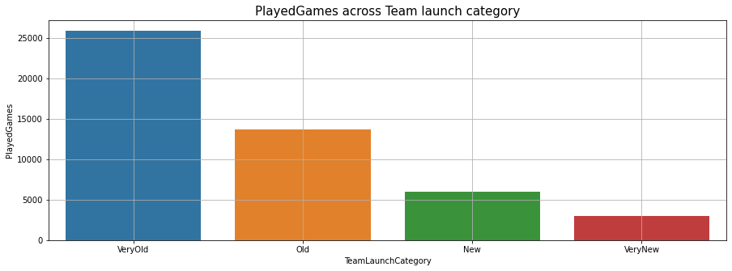

```python
gamesPlayed=df.sort_values('PlayedGames',ascending=False).groupby('TeamLaunchCategory')['PlayedGames'].sum().reset_index();

plt.figure(figsize=(15,5))
sns.barplot(x ='TeamLaunchCategory', y='PlayedGames' ,data = gamesPlayed)
plt.title("PlayedGames across Team launch category",size=15)
plt.grid()
plt.show()
```

### Observations:

- Teams coming in Very old category have played maximum games and in very new category , played lowest number of games.

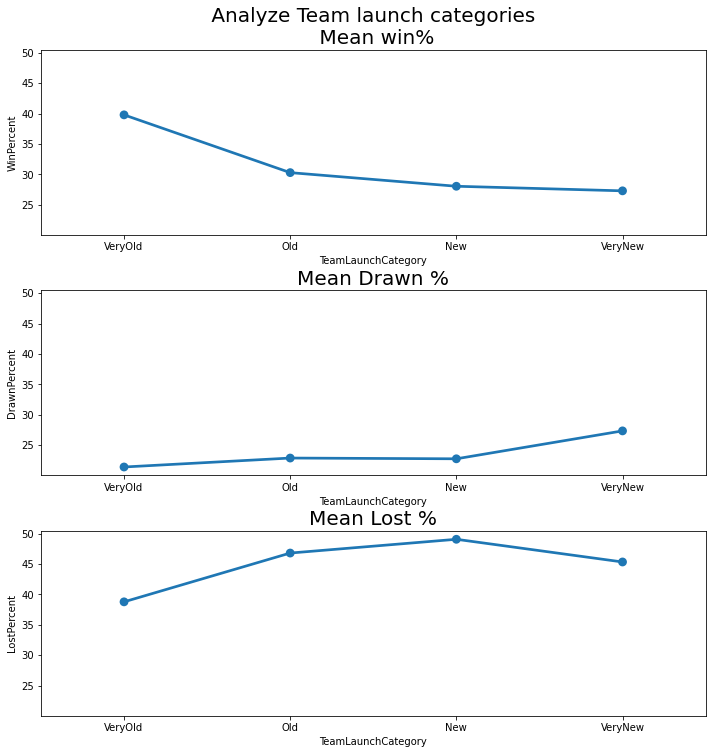

```python
groupLostMean=df.groupby(['TeamLaunchCategory'])['LostPercent'].mean().reset_index();
groupDrawnMean=df.groupby(['TeamLaunchCategory'])['DrawnPercent'].mean().reset_index();
groupWinMean=df.groupby(['TeamLaunchCategory'])['WinPercent'].mean().reset_index();

fig, ax =plt.subplots((3),figsize=(10, 10), sharey=True)

sns.pointplot(x=groupWinMean.TeamLaunchCategory,y=groupWinMean.WinPercent,data=groupWinMean,ax=ax[0]);
sns.pointplot(x=groupDrawnMean.TeamLaunchCategory,y=groupDrawnMean.DrawnPercent,data=groupDrawnMean,ax=ax[1]);
sns.pointplot(x=groupLostMean.TeamLaunchCategory,y=groupLostMean.LostPercent,data=groupLostMean,ax=ax[2]);

fig.tight_layout()
plt.subplots_adjust(hspace=0.3)
ax[0].set_title(" Analyze Team launch categories \n Mean win%",size='20')
ax[1].set_title("Mean Drawn %",size='20')
ax[2].set_title("Mean Lost %",size='20')

plt.show()
```

### Now, We draw some performance matrix plots:

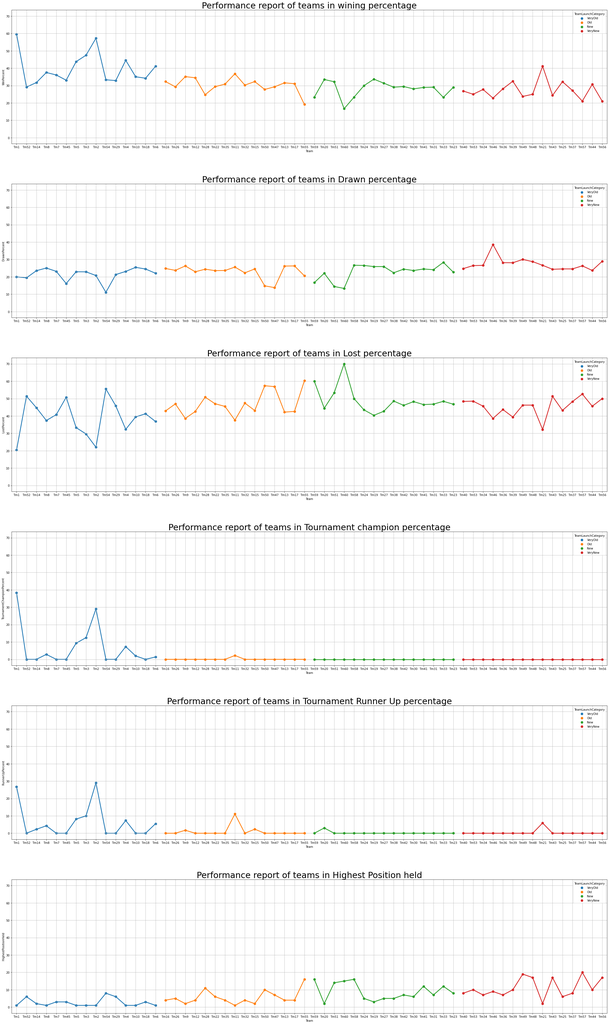

```python
SortedDf=(df.sort_values(['TeamLaunch'],ascending=[True]))
fig, ax =plt.subplots(6,figsize=(30, 50), sharey=True)

sns.pointplot(x='Team',y='WinPercent',hue='TeamLaunchCategory' ,data=SortedDf,ax=ax[0]);
sns.pointplot(x='Team',y='DrawnPercent',hue='TeamLaunchCategory' ,data=SortedDf,ax=ax[1]);
sns.pointplot(x='Team',y='LostPercent',hue='TeamLaunchCategory' ,data=SortedDf,ax=ax[2]);
sns.pointplot(x='Team',y='TournamentChampionPercent',hue='TeamLaunchCategory' ,data=SortedDf,ax=ax[3]);
sns.pointplot(x='Team',y='RunnerUpPercent',hue='TeamLaunchCategory' ,data=SortedDf,ax=ax[4]);
sns.pointplot(x='Team',y='HighestPositionHeld',hue='TeamLaunchCategory' ,data=SortedDf,ax=ax[5]);


fig.tight_layout()
plt.subplots_adjust(hspace=0.3)
ax[0].set_title("Performance report of teams in wining percentage",size='30')
ax[0].grid();
ax[1].set_title("Performance report of teams in Drawn percentage",size='30')
ax[1].grid();
ax[2].set_title("Performance report of teams in Lost percentage",size='30')
ax[2].grid();
ax[3].set_title("Performance report of teams in Tournament champion percentage",size='30')
ax[3].grid();
ax[4].set_title("Performance report of teams in Tournament Runner Up percentage",size='30')
ax[4].grid();
ax[5].set_title("Performance report of teams in Highest Position held",size='30')
ax[5].grid();
```

### Observations: